# Project: Investigate TMDb Movie Dataset

- Introduction
- Data Wrangling
- Exploratory Data Analysis
- Conclusions

## Introduction

This dataset is taken from *The Movie Database* (TMDb) and contains data collected for just over 10,000 movies from the years 1960 to 2015. The dataset contains information about each movie such as the genres it falls under, release date, user ratings, cast, production companies, budget, revenue and so on.

NumPy arrays and Pandas Series and DataFrames will be used in order address the following questions in this study.

## Questions posed:

### Q1: Which genres have the highest ratings on average?

### Q2: What are the top 10 production companies that have made the most money per year?

### Q3: What is the correlation between movie budget and average vote (do movies with a higher budget receive better ratings)?

### Import Packages

```python
# import numpy & pandas
import pandas as pd
import numpy as np

# import matplotlib for plotting graphs
import matplotlib.pyplot as plt

# 'magic word' so that visualizations are plotted inline with the notebook
%matplotlib inline
```

## Data Wrangling

### General Properties

```python
# Load data and print out a few lines

# Read csv into pandas dataframe and store as movies_df
movies_df = pd.read_csv('tmdb-movies.csv')

# View original movies dataframe
movies_df.head()
```

|  | id | imdb_id | popularity | budget | revenue | original_title | cast | homepage | director | tagline | ... | overview | runtime | genres | production_companies | release_date | vote_count | vote_average | release_year | budget_adj | revenue_adj |
| --- | --- | --- | --- | --- | --- | --- | --- | --- | --- | --- | --- | --- | --- | --- | --- | --- | --- | --- | --- | --- | --- |
| 0 | 135397 | tt0369610 | 32.985763 | 150000000 | 1513528810 | Jurassic World | Chris Pratt\|Bryce Dallas Howard\|Irrfan Khan\|Vi... | http://www.jurassicworld.com/ | Colin Trevorrow | The park is open. | ... | Twenty-two years after the events of Jurassic ... | 124 | Action\|Adventure\|Science Fiction\|Thriller | Universal Studios\|Amblin Entertainment\|Legenda... | 6/9/15 | 5562 | 6.5 | 2015 | 1.379999e+08 | 1.392446e+09 |
| 1 | 76341 | tt1392190 | 28.419936 | 150000000 | 378436354 | Mad Max: Fury Road | Tom Hardy\|Charlize Theron\|Hugh Keays-Byrne\|Nic... | http://www.madmaxmovie.com/ | George Miller | What a Lovely Day. | ... | An apocalyptic story set in the furthest reach... | 120 | Action\|Adventure\|Science Fiction\|Thriller | Village Roadshow Pictures\|Kennedy Miller Produ... | 5/13/15 | 6185 | 7.1 | 2015 | 1.379999e+08 | 3.481613e+08 |
| 2 | 262500 | tt2908446 | 13.112507 | 110000000 | 295238201 | Insurgent | Shailene Woodley\|Theo James\|Kate Winslet\|Ansel... | http://www.thedivergentseries.movie/#insurgent | Robert Schwentke | One Choice Can Destroy You | ... | Beatrice Prior must confront her inner demons ... | 119 | Adventure\|Science Fiction\|Thriller | Summit Entertainment\|Mandeville Films\|Red Wago... | 3/18/15 | 2480 | 6.3 | 2015 | 1.012000e+08 | 2.716190e+08 |
| 3 | 140607 | tt2488496 | 11.173104 | 200000000 | 2068178225 | Star Wars: The Force Awakens | Harrison Ford\|Mark Hamill\|Carrie Fisher\|Adam D... | http://www.starwars.com/films/star-wars-episod... | J.J. Abrams | Every generation has a story. | ... | Thirty years after defeating the Galactic Empi... | 136 | Action\|Adventure\|Science Fiction\|Fantasy | Lucasfilm\|Truenorth Productions\|Bad Robot | 12/15/15 | 5292 | 7.5 | 2015 | 1.839999e+08 | 1.902723e+09 |
| 4 | 168259 | tt2820852 | 9.335014 | 190000000 | 1506249360 | Furious 7 | Vin Diesel\|Paul Walker\|Jason Statham\|Michelle ... | http://www.furious7.com/ | James Wan | Vengeance Hits Home | ... | Deckard Shaw seeks revenge against Dominic Tor... | 137 | Action\|Crime\|Thriller | Universal Pictures\|Original Film\|Media Rights ... | 4/1/15 | 2947 | 7.3 | 2015 | 1.747999e+08 | 1.385749e+09 |

5 rows × 21 columns

```python
# Perform operations to inspect data types and look for instances of missing or possibly errant data
# also print out information about the data such as the mean, median for columns containing quantitative data
movies_df.describe()
```

|  | id | popularity | budget | revenue | runtime | vote_count | vote_average | release_year | budget_adj | revenue_adj |
| --- | --- | --- | --- | --- | --- | --- | --- | --- | --- | --- |
| count | 10866.000000 | 10866.000000 | 1.086600e+04 | 1.086600e+04 | 10866.000000 | 10866.000000 | 10866.000000 | 10866.000000 | 1.086600e+04 | 1.086600e+04 |
| mean | 66064.177434 | 0.646441 | 1.462570e+07 | 3.982332e+07 | 102.070863 | 217.389748 | 5.974922 | 2001.322658 | 1.755104e+07 | 5.136436e+07 |
| std | 92130.136561 | 1.000185 | 3.091321e+07 | 1.170035e+08 | 31.381405 | 575.619058 | 0.935142 | 12.812941 | 3.430616e+07 | 1.446325e+08 |
| min | 5.000000 | 0.000065 | 0.000000e+00 | 0.000000e+00 | 0.000000 | 10.000000 | 1.500000 | 1960.000000 | 0.000000e+00 | 0.000000e+00 |
| 25% | 10596.250000 | 0.207583 | 0.000000e+00 | 0.000000e+00 | 90.000000 | 17.000000 | 5.400000 | 1995.000000 | 0.000000e+00 | 0.000000e+00 |
| 50% | 20669.000000 | 0.383856 | 0.000000e+00 | 0.000000e+00 | 99.000000 | 38.000000 | 6.000000 | 2006.000000 | 0.000000e+00 | 0.000000e+00 |
| 75% | 75610.000000 | 0.713817 | 1.500000e+07 | 2.400000e+07 | 111.000000 | 145.750000 | 6.600000 | 2011.000000 | 2.085325e+07 | 3.369710e+07 |
| max | 417859.000000 | 32.985763 | 4.250000e+08 | 2.781506e+09 | 900.000000 | 9767.000000 | 9.200000 | 2015.000000 | 4.250000e+08 | 2.827124e+09 |

The statistical data above is useful to print out as we may need it to check variables in our investigation later on.

```python
# Gives no. of rows, columns as a tuple
movies_df.shape
```

```
(10866, 21)
```

```python
# Print information about the dataframe to see how many columns contain null data
movies_df.info()
```

```
<class 'pandas.core.frame.DataFrame'>
RangeIndex: 10866 entries, 0 to 10865
Data columns (total 21 columns):
id                      10866 non-null int64
imdb_id                 10856 non-null object
popularity              10866 non-null float64
budget                  10866 non-null int64
revenue                 10866 non-null int64
original_title          10866 non-null object
cast                    10790 non-null object
homepage                2936 non-null object
director                10822 non-null object
tagline                 8042 non-null object
keywords                9373 non-null object
overview                10862 non-null object
runtime                 10866 non-null int64
genres                  10843 non-null object
production_companies    9836 non-null object
release_date            10866 non-null object
vote_count              10866 non-null int64
vote_average            10866 non-null float64
release_year            10866 non-null int64
budget_adj              10866 non-null float64
revenue_adj             10866 non-null float64
dtypes: float64(4), int64(6), object(11)
memory usage: 1.7+ MB
```

After printing the information about the dataframe above, there are a few columns missing data such as: *imdb_id*, *cast*, *homepage*, *director*, *tagline*, *keywords*, *overview*, *genres* and *prodcution_companies* columns that are missing entries.

We will convert the columns separated by pipe (|) characters to a list. We will then deal with the missing data rows later in the analysis. This approach was chosen such that we do not remove all the rows that may contain useful data for other parameters/ columns.

### Data Cleaning

**Note:** The cells in this section should only be run once

**Step 1: Clean genres Column**

- Convert the rows in the genre column separated by pipe (|) characters to a list

```python
# Fill missing cast rows with the empty string, we will remove this data later on
# as you can't do the method below with NaN's and we do not want to remove data that
# we may want later on
movies_df = movies_df.fillna({'genres': ''})

# map loops through every row in the genres column and then applies [i.strip() for i in x.split("|")] to each row
# x.split("|") returns a pandas series using "|" as the delimiter string
# a conditional statement was used to only extract the rows which are not equal to the empty string
# so that the data is only of type list when the input data is not equal to the empty sting
movies_df['genres'] = movies_df.genres.map(lambda x:  [i.strip() for i in x.split("|")] if x != '' else x)
```

**Step 2: Clean cast Column**

- Convert the rows in the cast column separated by pipe (|) characters to a list

```python
# Fill missing cast rows with the empty string, we will remove this data later on
# as you can't do the method below with NaN's and we do not want to remove data that
# we may want later on
movies_df = movies_df.fillna({'cast': ''})

# map loops through every row in the genres column and then applies [i.strip() for i in x.split("|")] to each row
# x.split("|") returns a pandas series using "|" as the delimiter string
movies_df['cast'] = movies_df.cast.map(lambda x: [i.strip() for i in x.split("|")])
```

**Step 3: Clean production_companies Column**

- Convert the rows in the production_companies column separated by pipe (|) characters to a list

```python
# Fill missing production_companies rows with the empty string, we will remove this data later on
# as you can't do the method below with NaN's and we do not want to remove data that
# we may want later on
movies_df = movies_df.fillna({'production_companies': ''})

# map loops through every row in the genres column and then applies [i.strip() for i in x.split("|")] to each row
# x.split("|") returns a pandas series using "|" as the delimiter string
movies_df['production_companies'] = movies_df.production_companies.map(lambda x: [i.strip() for i in x.split("|")])
```

**Step 4: Add Net Income Column**

- Create a column for the net income, where:
- $income\:(net) = revenue - budget$

```python
# Create a column for the net income
# we use the columns with '_adj' to account for inflation over time (in terms of 2010 dollars)
net_income = movies_df['revenue_adj'] - movies_df['budget_adj']
movies_df['net_income_adj'] = net_income
```

```python
# View cleaned movies dataframe
movies_df.head(5)
```

|  | id | imdb_id | popularity | budget | revenue | original_title | cast | homepage | director | tagline | ... | runtime | genres | production_companies | release_date | vote_count | vote_average | release_year | budget_adj | revenue_adj | net_income_adj |
| --- | --- | --- | --- | --- | --- | --- | --- | --- | --- | --- | --- | --- | --- | --- | --- | --- | --- | --- | --- | --- | --- |
| 0 | 135397 | tt0369610 | 32.985763 | 150000000 | 1513528810 | Jurassic World | [Chris Pratt, Bryce Dallas Howard, Irrfan Khan... | http://www.jurassicworld.com/ | Colin Trevorrow | The park is open. | ... | 124 | [Action, Adventure, Science Fiction, Thriller] | [Universal Studios, Amblin Entertainment, Lege... | 6/9/15 | 5562 | 6.5 | 2015 | 1.379999e+08 | 1.392446e+09 | 1.254446e+09 |
| 1 | 76341 | tt1392190 | 28.419936 | 150000000 | 378436354 | Mad Max: Fury Road | [Tom Hardy, Charlize Theron, Hugh Keays-Byrne,... | http://www.madmaxmovie.com/ | George Miller | What a Lovely Day. | ... | 120 | [Action, Adventure, Science Fiction, Thriller] | [Village Roadshow Pictures, Kennedy Miller Pro... | 5/13/15 | 6185 | 7.1 | 2015 | 1.379999e+08 | 3.481613e+08 | 2.101614e+08 |
| 2 | 262500 | tt2908446 | 13.112507 | 110000000 | 295238201 | Insurgent | [Shailene Woodley, Theo James, Kate Winslet, A... | http://www.thedivergentseries.movie/#insurgent | Robert Schwentke | One Choice Can Destroy You | ... | 119 | [Adventure, Science Fiction, Thriller] | [Summit Entertainment, Mandeville Films, Red W... | 3/18/15 | 2480 | 6.3 | 2015 | 1.012000e+08 | 2.716190e+08 | 1.704191e+08 |
| 3 | 140607 | tt2488496 | 11.173104 | 200000000 | 2068178225 | Star Wars: The Force Awakens | [Harrison Ford, Mark Hamill, Carrie Fisher, Ad... | http://www.starwars.com/films/star-wars-episod... | J.J. Abrams | Every generation has a story. | ... | 136 | [Action, Adventure, Science Fiction, Fantasy] | [Lucasfilm, Truenorth Productions, Bad Robot] | 12/15/15 | 5292 | 7.5 | 2015 | 1.839999e+08 | 1.902723e+09 | 1.718723e+09 |
| 4 | 168259 | tt2820852 | 9.335014 | 190000000 | 1506249360 | Furious 7 | [Vin Diesel, Paul Walker, Jason Statham, Miche... | http://www.furious7.com/ | James Wan | Vengeance Hits Home | ... | 137 | [Action, Crime, Thriller] | [Universal Pictures, Original Film, Media Righ... | 4/1/15 | 2947 | 7.3 | 2015 | 1.747999e+08 | 1.385749e+09 | 1.210949e+09 |

5 rows × 22 columns

The following columns: *genres*, *cast* & *production_companies* have been converted into lists and the column *net_income_adj* (net income in dollars adjusted for year 2010) has been added to the dataframe, *movies_df*.

```python
# Confirm number of columns (we have added an additional column)
movies_df.shape
```

```
(10866, 22)
```

```python
# View column names
movies_df.columns
```

```
Index(['id', 'imdb_id', 'popularity', 'budget', 'revenue', 'original_title',
       'cast', 'homepage', 'director', 'tagline', 'keywords', 'overview',
       'runtime', 'genres', 'production_companies', 'release_date',
       'vote_count', 'vote_average', 'release_year', 'budget_adj',
       'revenue_adj', 'net_income_adj'],
      dtype='object')
```

## Exploratory Data Analysis

### Q1: Which genres have the highest ratings on average?

View trend for Average Vote Rating using a histogram and box plot

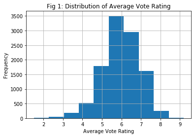

```python
# Let's plot a histogram for vote_average to see the trend
movies_df['vote_average'].hist()

plt.title('Fig 1: Distribution of Average Vote Rating')
plt.xlabel('Average Vote Rating')
plt.ylabel('Frequency');
```

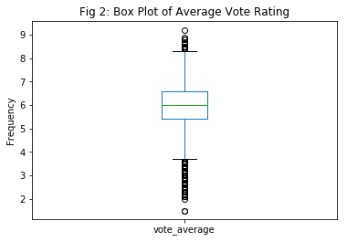

```python
# We can also plot a box plot to view the shape of the distribution
movies_df['vote_average'].plot(kind='box')

plt.title('Fig 2: Box Plot of Average Vote Rating')
plt.ylabel('Frequency');
```

The average vote rating across all movies is 5.97 out of 10, the median *average_vote* rating is 6 (this we can see both graphically in Fig 1 and Fig 2 and in the table *movies_df.describe()* in the *General Properties* Section above). The minimum average vote reating is 1.5 while the maximum is 9.2. The shape of the average vote rating data follows an almost symmetric/ normal distribution.

### Step 1:

Create dataframe with each genre type as a row and other variables repeated for each movie.

```python
# itertuples gives an iterator of named tuples
# for row in movies_df.itertuples(): first for loop which gives the whole row
# for genre in row.genres: this is the nested for loop, iterating each genre type for each movie
# row.column_name referes to the first for loop, thus column value is duplicated for each genre type
# genre refers to the nested for loop, each genre type in the list

result_df = pd.DataFrame([(genre, row.vote_average, row.vote_count, row.release_year, row.net_income_adj) \
                        for row in movies_df.itertuples() for genre in row.genres], \
                        columns=['genres', 'vote_average', 'vote_count', 'release_year', 'net_income_adj'])

# View the first 5 rows of this new dataframe
result_df.head()
```

|  | genres | vote_average | vote_count | release_year | net_income_adj |
| --- | --- | --- | --- | --- | --- |
| 0 | Action | 6.5 | 5562 | 2015 | 1.254446e+09 |
| 1 | Adventure | 6.5 | 5562 | 2015 | 1.254446e+09 |
| 2 | Science Fiction | 6.5 | 5562 | 2015 | 1.254446e+09 |
| 3 | Thriller | 6.5 | 5562 | 2015 | 1.254446e+09 |
| 4 | Action | 7.1 | 6185 | 2015 | 2.101614e+08 |

### Step 2:

Get the **arithmetic mean** vote rating for each genre type.

```python
# Groupby genres, taking the mean for each vote_average for each genre type
result_votes = result_df.groupby('genres', as_index=False)['vote_average'].mean()

# Sort vote_average from highest to lowest vote
result_votes = result_votes.sort_values('vote_average', ascending=False)

# Replace empty string with NaN and then drop the NaN row
result_votes.replace('', np.nan, inplace=True)
result_votes.dropna(inplace=True)

# Print sorted dataframe of mean vote_average for each genre type
result_votes
```

|  | genres | vote_average |
| --- | --- | --- |
| 5 | Documentary | 6.908462 |
| 12 | Music | 6.480392 |
| 10 | History | 6.410479 |
| 2 | Animation | 6.403147 |
| 18 | War | 6.297778 |
| 6 | Drama | 6.165301 |
| 4 | Crime | 6.124059 |
| 19 | Western | 6.083030 |
| 14 | Romance | 6.042874 |
| 7 | Family | 5.997563 |
| 9 | Foreign | 5.981383 |
| 13 | Mystery | 5.946790 |
| 1 | Adventure | 5.940585 |
| 3 | Comedy | 5.905167 |
| 8 | Fantasy | 5.863537 |
| 16 | TV Movie | 5.788024 |
| 0 | Action | 5.787421 |
| 17 | Thriller | 5.750413 |
| 15 | Science Fiction | 5.665041 |
| 11 | Horror | 5.337447 |

View the trend of mean vote_average for each genre type graphically in a bar graph.

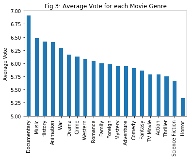

```python
# Plot a bar graph of each genre type's average vote
result_votes['vote_average'].plot(kind='bar')

plt.title('Fig 3: Average Vote for each Movie Genre')
plt.ylabel('Average Vote')

plt.xticks([0,1,2,3,4,5,6,7,8,9,10,11,12,13,14,15,16,17,18,19], \
           result_votes.sort_values('vote_average', ascending=False)['genres']);

# Limit y-axis to show between 5 and 7
# gca = get current axes
axes = plt.gca()
axes.set_ylim([5, 7]);
```

The average user rating for each genre type is depicted graphically in Fig 3. Here we see that Documentary has the highest average vote (6.90/10), followed by Music and History. Horror (rating score: 5.34/10) had the lowest average user rating.

### Step 3:

Instead of using the mean *vote_average* for each genre type, a more accurate comparison would be to use the **weighted average** for each genre type thus taking the vote count into account. The weighted average is similar to the arithmetic mean (average), except each data point does not contribute equally to the final average value. Instead, some data points contribute more to the final average than others as each data point has a weight associated with each point and these weightings determine the relative importance of each data point on the overall average.

The weighted average is defined as:

$$weighted\: average =\frac{\sum_{i=1}^n(v_i*w_i)}{\sum_{i=1}^n w_i}$$

$$where: v_i = vote\ average, w_i = vote\ count$$

```python
# Groupby genres, taking the weighted mean for vote_average for each genre type
# The numpy function applies the weighted average definition above
weighted_averages_result = result_df.groupby('genres').apply(lambda x: np.average(x['vote_average'], weights=x['vote_count']))

# Convert Series to DataFrame and use reset_index to make the genres index a column
weighted_averages_result_df = pd.DataFrame(weighted_averages_result, columns=['weighted_vote_average']).reset_index()

# Sort vote_average from highest to lowest vote
weighted_averages_result_df = weighted_averages_result_df.sort_values('weighted_vote_average', ascending=False)

# Print sorted dataframe of weighted averages for each genre type
weighted_averages_result_df
```

|  | genres | weighted_vote_average |
| --- | --- | --- |
| 5 | Documentary | 7.072342 |
| 18 | War | 7.021921 |
| 10 | History | 6.993177 |
| 6 | Drama | 6.840895 |
| 2 | Animation | 6.819854 |
| 19 | Western | 6.797800 |
| 4 | Crime | 6.744651 |
| 12 | Music | 6.697110 |
| 13 | Mystery | 6.663521 |
| 7 | Family | 6.648997 |
| 1 | Adventure | 6.632753 |
| 15 | Science Fiction | 6.613327 |
| 8 | Fantasy | 6.551695 |
| 0 | Action | 6.547522 |
| 14 | Romance | 6.526093 |
| 17 | Thriller | 6.520928 |
| 3 | Comedy | 6.392141 |
| 9 | Foreign | 6.101088 |
| 11 | Horror | 6.041762 |
| 16 | TV Movie | 5.731608 |

View the trend of the weighted average vote ratings for each genre type graphically in a bar graph.

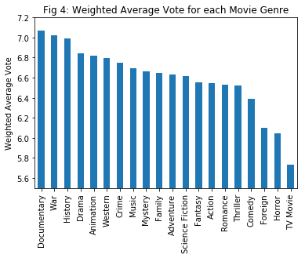

```python
# Plot a bar graph of each genre type's weighted average vote
weighted_averages_result_df['weighted_vote_average'].plot(kind='bar')

plt.title('Fig 4: Weighted Average Vote for each Movie Genre')
plt.ylabel('Weighted Average Vote')

plt.xticks([0,1,2,3,4,5,6,7,8,9,10,11,12,13,14,15,16,17,18,19], \
           weighted_averages_result_df.sort_values('weighted_vote_average', ascending=False)['genres'])

# Limit y-axis to show between 5.5 and 7.2
# gca = get current axes
axes = plt.gca()
axes.set_ylim([5.5, 7.2]);
```

The weighted average user rating for each genre type is depicted graphically in Fig 4. Here we see that again Documentary has the highest average vote (7.07/10), followed by War and History. TV Movie (rating score: 5.73/10) had the lowest weighted average user rating. By taking the vote count into account as the weights in the weighted average calculation, we get slightly different results to those not taking the vote count into account (Fig 3).

Using the weighted aveage over the arithmetic mean is more accurate as instead of each data point contributing equally to the overall average, data points associated with a higher weighting (more vote counts) contibute more to the final average value.

### Q2: What are the top 10 production companies that have made the most money per year?

```python
# Extract certain columns from the movies dataframe and store in genres_df
genres_df = movies_df[['original_title', 'genres', 'vote_average', 'popularity', 'release_year']]

genres_df.head(10)
```

|  | original_title | genres | vote_average | popularity | release_year |
| --- | --- | --- | --- | --- | --- |
| 0 | Jurassic World | [Action, Adventure, Science Fiction, Thriller] | 6.5 | 32.985763 | 2015 |
| 1 | Mad Max: Fury Road | [Action, Adventure, Science Fiction, Thriller] | 7.1 | 28.419936 | 2015 |
| 2 | Insurgent | [Adventure, Science Fiction, Thriller] | 6.3 | 13.112507 | 2015 |
| 3 | Star Wars: The Force Awakens | [Action, Adventure, Science Fiction, Fantasy] | 7.5 | 11.173104 | 2015 |
| 4 | Furious 7 | [Action, Crime, Thriller] | 7.3 | 9.335014 | 2015 |
| 5 | The Revenant | [Western, Drama, Adventure, Thriller] | 7.2 | 9.110700 | 2015 |
| 6 | Terminator Genisys | [Science Fiction, Action, Thriller, Adventure] | 5.8 | 8.654359 | 2015 |
| 7 | The Martian | [Drama, Adventure, Science Fiction] | 7.6 | 7.667400 | 2015 |
| 8 | Minions | [Family, Animation, Adventure, Comedy] | 6.5 | 7.404165 | 2015 |
| 9 | Inside Out | [Comedy, Animation, Family] | 8.0 | 6.326804 | 2015 |

### Step 1:

Create dataframe with each production company as a row and all other variables repeated for each movie.

```python
# itertuples gives an iterator of named tuples
# for row in movies_df.itertuples(): first for loop which gives the whole row
# for company in row.production_companies: nested for loop, iterating each company in the production_companies column
# row.column_name referes to the first for loop, thus column value is duplicated for each production company

result_df_2 = pd.DataFrame([(company, row.vote_average, row.popularity, row.release_year, row.net_income_adj) \
                       for row in movies_df.itertuples() for company in row.production_companies], \
                      columns=['production_company', 'vote_average', 'popularity', 'release_year', 'net_income_adj'])

# Print dataframe
result_df_2.head(10)
```

|  | production_company | vote_average | popularity | release_year | net_income_adj |
| --- | --- | --- | --- | --- | --- |
| 0 | Universal Studios | 6.5 | 32.985763 | 2015 | 1.254446e+09 |
| 1 | Amblin Entertainment | 6.5 | 32.985763 | 2015 | 1.254446e+09 |
| 2 | Legendary Pictures | 6.5 | 32.985763 | 2015 | 1.254446e+09 |
| 3 | Fuji Television Network | 6.5 | 32.985763 | 2015 | 1.254446e+09 |
| 4 | Dentsu | 6.5 | 32.985763 | 2015 | 1.254446e+09 |
| 5 | Village Roadshow Pictures | 7.1 | 28.419936 | 2015 | 2.101614e+08 |
| 6 | Kennedy Miller Productions | 7.1 | 28.419936 | 2015 | 2.101614e+08 |
| 7 | Summit Entertainment | 6.3 | 13.112507 | 2015 | 1.704191e+08 |
| 8 | Mandeville Films | 6.3 | 13.112507 | 2015 | 1.704191e+08 |
| 9 | Red Wagon Entertainment | 6.3 | 13.112507 | 2015 | 1.704191e+08 |

### Step 2:

Get the mean net income (in terms of 2010 dollar, accounting for inflation over time) for each production company

```python
# Groupby production_companies, taking the mean for each net_income_adj for each company
result_income = result_df_2.groupby(['production_company', 'release_year'], as_index=False)['net_income_adj'].mean()

# sort net_income_adj from highest to lowest vote
result_income = result_income.sort_values('net_income_adj', ascending=False)

# Replace empty string with NaN and then drop the NaN row
result_income.replace('', np.nan, inplace=True)
result_income.dropna(inplace=True)

# Print sorted top 10 production companies dataframe
top_10_df = result_income.head(10)
top_10_df
```

|  | production_company | release_year | net_income_adj |
| --- | --- | --- | --- |
| 8212 | Lucasfilm | 1977 | 2.750137e+09 |
| 7986 | Lightstorm Entertainment | 2009 | 2.586237e+09 |
| 7984 | Lightstorm Entertainment | 1997 | 2.234714e+09 |
| 6499 | Hoya Productions | 1973 | 2.128036e+09 |
| 15650 | Zanuck/Brown Productions | 1975 | 1.878643e+09 |
| 694 | Amblin Entertainment | 1982 | 1.767968e+09 |
| 14186 | Truenorth Productions | 2015 | 1.718723e+09 |
| 8213 | Lucasfilm | 1980 | 1.376998e+09 |
| 15000 | Walt Disney Pictures | 1967 | 1.319404e+09 |
| 14608 | Universal Studios | 2015 | 1.254446e+09 |

View the trend of the top 10 production companies with the highest income made in a year period graphically in a bar graph.

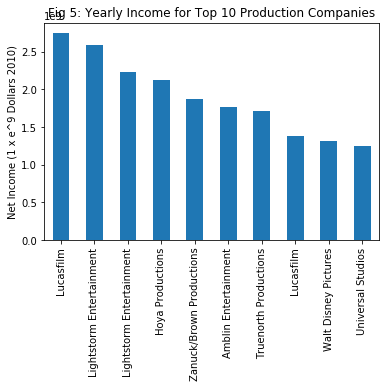

```python
# Plot a bar graph of each genre types weighted average vote
top_10_df['net_income_adj'].plot(kind='bar')

plt.title('Fig 5: Yearly Income for Top 10 Production Companies')
plt.ylabel('Net Income (1 x e^9 Dollars 2010)')

plt.xticks([0,1,2,3,4,5,6,7,8,9], \
           top_10_df.sort_values('net_income_adj', ascending=False)['production_company']);
```

### Q3: What is the correlation between movie budget and average vote (do movies with a higher budget receive better ratings)?

View the trend for movie budget using a histogram and box plot

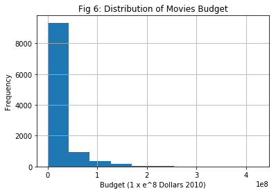

```python
# Let's plot a histogram for budget_adj to see the trend
movies_df['budget_adj'].hist()

plt.title('Fig 6: Distribution of Movies Budget')
plt.xlabel('Budget (1 x e^8 Dollars 2010)')
plt.ylabel('Frequency');
```

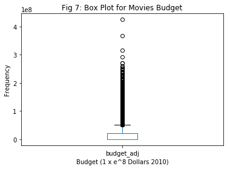

```python
# We can also plot a box plot to view the shape of the distribution
movies_df['budget_adj'].plot(kind='box')

plt.title('Fig 7: Box Plot for Movies Budget')
plt.xlabel('Budget (1 x e^8 Dollars 2010)')
plt.ylabel('Frequency');
```

The vast majority of the data seems to be falling in the bin between 0 - 1 *e^8, we see this from both the box plot (Fig 7) as well as the histogram (Fig 6) where the data is heavily skewed to the right.

There may be values where the *Budget* is zero, if there is, then the rows associated with a Budget value of zero will need to be discarded. For the purpose of this study, all movies with a budget less than 1 million Dollars were excluded.

### Clean Data for when the budget is less than one million dollars

This is not done in the Data Wrangling Section as we do not want to remove all rows where the Budget is less than one million dollars. Thus we create a new DataFrame and remove the rows associated with the new DataFrame (that are less than one million dollars), giving the rows of data we only want for this question.

```python
# Extract certain columns from the movies dataframe and store in budget_vote_df
budget_vote_df = movies_df[['vote_average', 'budget_adj']]

# View the shape
budget_vote_df.shape
```

```
(10866, 2)
```

```python
# Here we see that there are rows where budget is zero (min value for budget_adj)
budget_vote_df.describe()
```

|  | vote_average | budget_adj |
| --- | --- | --- |
| count | 10866.000000 | 1.086600e+04 |
| mean | 5.974922 | 1.755104e+07 |
| std | 0.935142 | 3.430616e+07 |
| min | 1.500000 | 0.000000e+00 |
| 25% | 5.400000 | 0.000000e+00 |
| 50% | 6.000000 | 0.000000e+00 |
| 75% | 6.600000 | 2.085325e+07 |
| max | 9.200000 | 4.250000e+08 |

```python
# Exclude rows where Budget is less than one million dollars
budget_vote_df_cleaned = budget_vote_df[budget_vote_df.budget_adj >= 1000000]

# Print first 5 rows of cleaned dataframe
budget_vote_df_cleaned.head()
```

|  | vote_average | budget_adj |
| --- | --- | --- |
| 0 | 6.5 | 1.379999e+08 |
| 1 | 7.1 | 1.379999e+08 |
| 2 | 6.3 | 1.012000e+08 |
| 3 | 7.5 | 1.839999e+08 |
| 4 | 7.3 | 1.747999e+08 |

```python
# How many rows do we have left?
budget_vote_df_cleaned.shape
```

```
(4843, 2)
```

We have 4,843 rows left, more than half of the dataset was removed by removing the rows where the budget is less than one million dollars! A lot of the movie budget data is missing from the dataset. There is still adequate data to analyse.

```python
# Check min and max values
budget_vote_df_cleaned.describe()
```

|  | vote_average | budget_adj |
| --- | --- | --- |
| count | 4843.000000 | 4.843000e+03 |
| mean | 6.048709 | 3.935250e+07 |
| std | 0.863276 | 4.222795e+07 |
| min | 2.200000 | 1.000000e+06 |
| 25% | 5.500000 | 1.016400e+07 |
| 50% | 6.100000 | 2.531967e+07 |
| 75% | 6.600000 | 5.282824e+07 |
| max | 8.400000 | 4.250000e+08 |

The minimum values have now been limited to one million Dollars as confirmed by the table above.

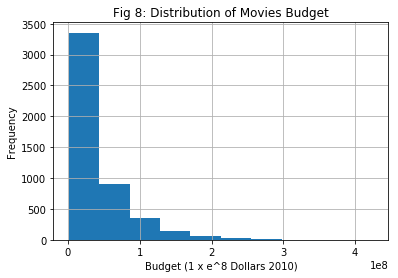

```python
# Let's plot a histogram for the new dataset where we exclude the rows where Budget < 1 million dollars
budget_vote_df_cleaned['budget_adj'].hist()

plt.title('Fig 8: Distribution of Movies Budget')
plt.xlabel('Budget (1 x e^8 Dollars 2010)')
plt.ylabel('Frequency');
```

The data is still skewed to the right, although not as heavily as in Fig 6.

View the trend of the scatter plot for movies budget vs. average vote.

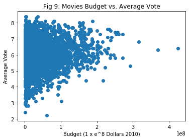

```python
# Let's plot a scatter graph for movies budget vs. average vote
plt.scatter(budget_vote_df_cleaned['budget_adj'], budget_vote_df_cleaned['vote_average'])

plt.title('Fig 9: Movies Budget vs. Average Vote')
plt.xlabel('Budget (1 x e^8 Dollars 2010)')
plt.ylabel('Average Vote');
```

### Calculate Pearson's r / Correlation Coefficient

```python
# Calculate the correlation coefficient using NumPy's built in function
# indexing [0][1] gives the correlation of x,y
r = np.corrcoef(movies_df['budget_adj'], movies_df['vote_average'])[0][1]

# print Pearson's r
print(r)
```

```
0.0930389817834
```

## Conclusions

### Q1: Which movie genres have the highest ratings on average?

In this question, we investigated which movie genres have the highest ratings on average.

This was done in two ways:

1. Using the **mean** function to find the mean vote rating for each genre
2. Using NumPy's **weighted average** function to find the weighted average vote rating for each genre

The following 3 movie genres had the **best** vote ratings for each method:

| Method | Movie Genre | Vote Rating |
| --- | --- | --- |
| 1 | Documentary | 6.90 |
| 1 | Music | 6.48 |
| 1 | History | 6.41 |
| 2 | Documentary | 7.07 |
| 2 | War | 7.02 |
| 2 | History | 6.99 |

The following 3 movie genres had the **worst** vote ratings for each method:

| Method | Movie Genre | Vote Rating |
| --- | --- | --- |
| 1 | Thriller | 5.75 |
| 1 | Science Fiction | 5.66 |
| 1 | Horror | 5.34 |
| 2 | Foreign | 6.10 |
| 2 | Horror | 6.04 |
| 2 | TV Movie | 5.73 |

Using Method 2, the weighted averages, the vote count was taken into account for each genre type hence the results are slightly different. For both methods movies that fall under the Documentary genre seem to get the best votes on average. Horror movies seem to be among the genre that receives the least amount of votes.

### Q2: What are the top 10 production companies that have made the most money per year?

The results for this question are depicted graphically in Fig 5. Here we see that LucasFilm made the most money in a year period with a whopping 2.75e+09 Dollars (in terms of Dollars 2010) in 1977, this was the year of the release of Star Wars: Episode IV – A New Hope.

### Limitations

Although this dataset looked very itriguing to begin with, most of the data provided was categorical nominal data with some quantitative data. Much of the categorical data overlapped with other movies making it difficult to infer that any one factor was better than another. For example, Science Fiction was not among the most popular genre types, however, LucasFilm released Star Wars Episode IV – A New Hope in 1977, the year in which LucasFilm made the most income out of any other production company in the dataset.

Multiple variables (some of which cannot be quantified easily) affect a movies user rating and net income (these are not the only variables which quantify a movies success but are probably the most important), this may differ for every movie and comparing data with one another does not yield much useful insight into determining whether or not a movie will be successful. Production company, cast and the director (among many other factors) do play an important role in whether or not a movie is succesful, a more in depth study needs to be done in order to determine which factors make a movie successful, however, the answer is still not cut and dry.

```python
from subprocess import call
call(['python', '-m', 'nbconvert', 'Investigate_a_Dataset.ipynb'])
```

```
0
```

## REFERENCES

- https://www.dataquest.io/blog/pandas-cheat-sheet/
- https://docs.python.org/3/library/stdtypes.html#str.split
- http://chris.friedline.net/2015-12-15-rutgers/lessons/python2/02-index-slice-subset.html
- https://pandas.pydata.org/pandas-docs/stable/generated/pandas.Series.map.html
- https://pandas.pydata.org/pandas-docs/stable/generated/pandas.DataFrame.itertuples.html
- https://pandas.pydata.org/pandas-docs/stable/generated/pandas.DataFrame.fillna.html
- https://stackoverflow.com/questions/23857756/mapping-a-lambda-function-to-lists-of-strings-fails-float-object-not-iterabl
- https://stackoverflow.com/questions/17006641/single-line-nested-for-loops
- https://stackoverflow.com/questions/11285613/selecting-columns-in-a-pandas-dataframe
- https://stackoverflow.com/questions/38203352/expand-pandas-dataframe-column-into-multiple-rows
- https://stackoverflow.com/questions/29314033/python-pandas-dataframe-remove-empty-cells
- https://pandas.pydata.org/pandas-docs/stable/generated/pandas.DataFrame.html
- https://pandas.pydata.org/pandas-docs/stable/generated/pandas.DataFrame.dropna.html
- https://pandas.pydata.org/pandas-docs/stable/generated/pandas.DataFrame.replace.html
- http://pandas.pydata.org/pandas-docs/stable/generated/pandas.DataFrame.sort_values.html
- https://pandas.pydata.org/pandas-docs/stable/generated/pandas.DataFrame.apply.html
- http://data-blog.udacity.com/posts/2016/10/latex-primer/
- http://www.onemathematicalcat.org/MathJaxDocumentation/TeXSyntax.htm
- https://docs.scipy.org/doc/numpy-1.13.0/reference/generated/numpy.average.html
- http://songhuiming.github.io/pages/2017/03/18/weighted-avarage-aggrefated-function-with-apply-and-agg/
- http://blog.yhat.com/tutorials/4-Aggregation-and-Grouping.html
- https://pandas.pydata.org/pandas-docs/stable/generated/pandas.DataFrame.reset_index.html
- https://stackoverflow.com/questions/17839973/construct-pandas-dataframe-from-values-in-variables
- https://stackoverflow.com/questions/18837262/convert-python-dict-into-a-dataframe/32344037
- https://stackoverflow.com/questions/20490274/how-to-reset-index-in-a-pandas-data-frame
- http://pbpython.com/weighted-average.html
- https://docs.scipy.org/doc/numpy-1.13.0/reference/generated/numpy.corrcoef.html